# Predictive analysis of Bank Marketing

# Hyperparameters and GridSearchCV

```python
X_train, X_test, y_train, y_test = split_data(dfTransformed, drop_list)

# decision tree parameter findings using GridSearchCV

parameters={'min_samples_split' : range(10,100,10),'max_depth': range(1,20,2), 'criterion' :['gini', 'entropy']}
clf_tree=tree.DecisionTreeClassifier()
clf = GridSearchCV(estimator=clf_tree, param_grid=parameters, cv=5)
clf.fit(X_train, y_train)
print("Decision Tree :\n", clf.best_params_)
```

```
Index(['age', 'job', 'balance', 'day', 'month', 'duration', 'campaign',
       'previous', 'poutcome', 'Target'],
      dtype='object')
Decision Tree :
 {'criterion': 'gini', 'max_depth': 5, 'min_samples_split': 60}
```

```python
# random forest parameter findings using GridSearchCV
X_train, X_test, y_train, y_test = split_data(dfTransformed, drop_list)

parameters = {
    'n_estimators': [200, 500],
    'max_features': ['auto', 'sqrt', 'log2'],
    'max_depth' : [4,5,6,7,8],
    'criterion' :['gini', 'entropy']
}
rfc=RandomForestClassifier(random_state=42)
clf_rfc = GridSearchCV(estimator=rfc, param_grid=parameters, cv= 5)
clf_rfc.fit(X_train, y_train)
print("Random Forest :\n", clf_rfc.best_params_)
```

```
Index(['age', 'job', 'balance', 'day', 'month', 'duration', 'campaign',
       'previous', 'poutcome', 'Target'],
      dtype='object')
Random Forest :
 {'criterion': 'gini', 'max_depth': 8, 'max_features': 'auto', 'n_estimators': 200}
```

Run the Decision Classifier and Random Forest based on the outcome of the GridSearch

Decision Tree : {'criterion': 'gini', 'max_depth': 5, 'min_samples_split': 60}

Random Forest :{'criterion': 'gini', 'max_depth': 8, 'max_features': 'auto', 'n_estimators': 200}

```
============================== GridSearchCV-DecisionTree Model Starts ==============================
Index(['age', 'job', 'marital', 'education', 'default', 'balance', 'housing',
       'loan', 'contact', 'day', 'month', 'duration', 'campaign', 'previous',
       'poutcome', 'Target'],
      dtype='object')
Train-set confusion matrix:
 [[31249   688]
 [ 2824  1407]]
============================== GridSearchCV-DecisionTree Model Evaluation ==============================
Accuracy score:
 0.8991485126617274
Test-set confusion matrix:
 [[7803  182]
 [ 730  328]]
Classification report:
               precision    recall  f1-score   support

           0       0.91      0.98      0.94      7985
           1       0.64      0.31      0.42      1058

   micro avg       0.90      0.90      0.90      9043
   macro avg       0.78      0.64      0.68      9043
weighted avg       0.88      0.90      0.88      9043

ROC AUC: 0.8637953014454086
```

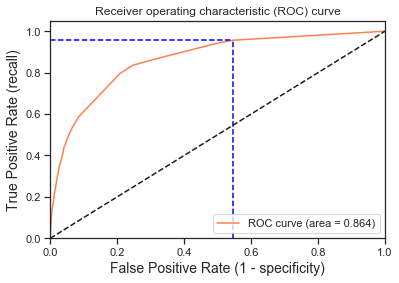

```
Using a threshold of 0.038 guarantees a sensitivity of 0.957 and a specificity of 0.453, i.e. a false positive rate of 54.69%.
============================== GridSearchCV-DecisionTree Model Ends ==============================


============================== RandomForest Model Starts ==============================
Index(['age', 'job', 'marital', 'education', 'default', 'balance', 'housing',
       'loan', 'contact', 'day', 'month', 'duration', 'campaign', 'previous',
       'poutcome', 'Target'],
      dtype='object')
Train-set confusion matrix:
 [[31789   148]
 [ 3312   919]]
============================== RandomForest Model Evaluation ==============================
Accuracy score:
 0.8979321021784806
Test-set confusion matrix:
 [[7926   59]
 [ 864  194]]
Classification report:
               precision    recall  f1-score   support

           0       0.90      0.99      0.94      7985
           1       0.77      0.18      0.30      1058

   micro avg       0.90      0.90      0.90      9043
   macro avg       0.83      0.59      0.62      9043
weighted avg       0.89      0.90      0.87      9043

ROC AUC: 0.9120903679275768
```

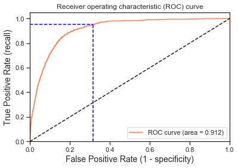

```
Using a threshold of 0.071 guarantees a sensitivity of 0.951 and a specificity of 0.684, i.e. a false positive rate of 31.56%.
============================== RandomForest Model Ends ==============================
```

```python
drop_list = [] #to drop columns not affecting the model output
models = []

models.append(('GridSearchCV-DecisionTree',
               DecisionTreeClassifier(criterion='gini', max_depth=5, min_samples_split=60)))
models.append(('RandomForest',
               RandomForestClassifier(criterion='gini', max_depth=8, max_features='auto', n_estimators=200)))

for i,v in models:
    print('============================== {} Model Starts =============================='.format(i))
    X_train, X_test, y_train, y_test = split_data(dfTransformed, drop_list)
    y_pred, y_pred_prob = get_predictions(v, X_train, y_train, X_test)
    print('============================== {} Model Evaluation =============================='.format(i))
    print_scores(y_test,y_pred,y_pred_prob)
    [fpr, tpr, thr] = roc_curve(y_test, y_pred_prob[:,1])
    roc_curve_draw(fpr, tpr, thr)
    print('============================== {} Model Ends =============================='.format(i))
    print('\n')
```

```python
# parameters = {
#     "learning_rate": [0.01, 0.05, 0.1], # on giving multiple list, notebook was not responding so limited the rate list
#     "max_depth":[3,5,8],
#     "max_features":["log2","sqrt"],
#     "criterion": ["friedman_mse",  "mae"],
#     "n_estimators":[10]
#     }

p_test3 = {'learning_rate':[0.15,0.1,0.05,0.01,0.005,0.001], 'n_estimators':[100,250,500,750,1000,1250,1500,1750]}

clfGD = GridSearchCV(estimator = GradientBoostingClassifier(max_depth=4, min_samples_split=2, min_samples_leaf=1,
                                                           subsample=1,max_features='sqrt', random_state=10),
            param_grid = p_test3, scoring='accuracy',n_jobs=4,iid=False, cv=5)

# clfGD = GridSearchCV(GradientBoostingClassifier(), parameters, cv=5, n_jobs=2)
clfGD.fit(X_train, y_train)
print("Gradient Boosting Parameters :\n", clfGD.best_params_)
```

```
Gradient Boosting Parameters :
 {'learning_rate': 0.1, 'n_estimators': 750}
```

```
============================== GridSearchCV-GBM Model Starts ==============================
Index(['age', 'job', 'marital', 'education', 'default', 'balance', 'housing',
       'loan', 'contact', 'day', 'month', 'duration', 'campaign', 'previous',
       'poutcome', 'Target'],
      dtype='object')
Train-set confusion matrix:
 [[31393   544]
 [ 1655  2576]]
============================== GridSearchCV-GBM Model Evaluation ==============================
Accuracy score:
 0.9041247373659184
Test-set confusion matrix:
 [[7697  288]
 [ 579  479]]
Classification report:
               precision    recall  f1-score   support

           0       0.93      0.96      0.95      7985
           1       0.62      0.45      0.52      1058

   micro avg       0.90      0.90      0.90      9043
   macro avg       0.78      0.71      0.74      9043
weighted avg       0.89      0.90      0.90      9043

ROC AUC: 0.922757225563527
```

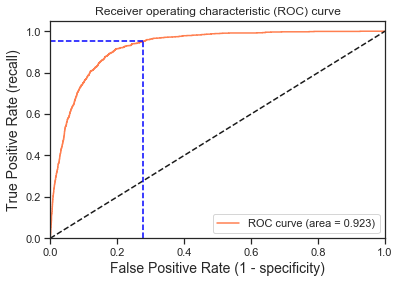

```
Using a threshold of 0.042 guarantees a sensitivity of 0.951 and a specificity of 0.724, i.e. a false positive rate of 27.61%.
============================== GridSearchCV-GBM Model Ends ==============================


============================== GridSearchCV-ABM Model Starts ==============================
Index(['age', 'job', 'marital', 'education', 'default', 'balance', 'housing',
       'loan', 'contact', 'day', 'month', 'duration', 'campaign', 'previous',
       'poutcome', 'Target'],
      dtype='object')
Train-set confusion matrix:
 [[31153   784]
 [ 2826  1405]]
============================== GridSearchCV-ABM Model Evaluation ==============================
Accuracy score:
 0.8974897710936636
Test-set confusion matrix:
 [[7769  216]
 [ 711  347]]
Classification report:
               precision    recall  f1-score   support

           0       0.92      0.97      0.94      7985
           1       0.62      0.33      0.43      1058

   micro avg       0.90      0.90      0.90      9043
   macro avg       0.77      0.65      0.69      9043
weighted avg       0.88      0.90      0.88      9043

ROC AUC: 0.9047980440641893
```

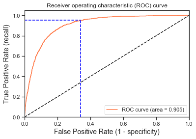

```
Using a threshold of 0.490 guarantees a sensitivity of 0.951 and a specificity of 0.659, i.e. a false positive rate of 34.05%.
============================== GridSearchCV-ABM Model Ends ==============================
```

```python
drop_list = [] #to drop columns not affecting the model output
models = []

models.append(('GridSearchCV-GBM',
               GradientBoostingClassifier(max_depth=4, min_samples_split=2, min_samples_leaf=1,
                                          subsample=1,max_features='sqrt', random_state=10,
                                          learning_rate=0.1, n_estimators=750)))
models.append(('GridSearchCV-ABM',
               AdaBoostClassifier(random_state=10, learning_rate=0.1, n_estimators=750)))
for i,v in models:
    print('============================== {} Model Starts =============================='.format(i))
    X_train, X_test, y_train, y_test = split_data(dfTransformed, drop_list)
    y_pred, y_pred_prob = get_predictions(v, X_train, y_train, X_test)
    print('============================== {} Model Evaluation =============================='.format(i))
    print_scores(y_test,y_pred,y_pred_prob)
    [fpr, tpr, thr] = roc_curve(y_test, y_pred_prob[:,1])
    roc_curve_draw(fpr, tpr, thr)
    print('============================== {} Model Ends =============================='.format(i))
    print('\n')
```

**Summary Report After GridSearchCV -**

Since notebook was not responding I evaluated only GBM. And we can see that with 92% ROC value it outperformed other ensemble methods

# GBM works well when performing the Grid SearchCV, ROC is 92.2% and Sensitivity is 95.1%

**Note-** because of notebook unresponsiveness when using hyperparamters, I havent calculated tother hyperparameters

# Summary Report